# Usando Regressão

Rayssa

15 de agosto de 2017

# Dados

Os dados que iremos utilizar neste post estão disponíveis neste link https://github.com/nazareno/ciencia-de-dados-1/tree/master/5-regressao/speed-dating e descrevem 5000 encontros relâmpagos (speed dating) de 4 minutos envolvendo 310 jovens americanos. Os dados originais foram coletados por professores da Columbia Business School.

Os participantes tinham vários encontros de 4 minutos por noite. Após cada um, preenchiam fichas avaliando aqueles com quem se encontraram. Cada linha nos dados representa um desses encontros.

Para esta análise utilizaremos as seguintes variáveis:  
*gender : sexo da pessoa que avalia (0 = mulher, 1 = homem)*  
attr(atração) : é o quão atraente p1 achou p2  
*sinc(sinceridade) : é o quão sincero p1 achou p2*  
like : no geral, quanto p1 gostou de p2?

Neste post iremos analisar a avaliação das mulheres e dos homens em relação aos seus encontros, de acordo com as características **sinceridade** e **atração**; buscando responder a seguinte pergunta: **Qual característica (sinceridade ou atração) tem maior relação com o fato da pessoa, no geral, gostar da outra depois do encontro speed dating?**

Vamos responder esta pergunta na visão dos homens e das mulheres. Para isso devemos separar os dados em dois grupos *mulheres* e *homens*. Primeiro iremos verificar as avaliações dos homens e logo após as das mulheres.

```r
advertising = read_csv("../dados/speed-dating.csv")
```

# Homens avaliando seus encontros

Inicialmente iremos filtrar os dados com pessoas de gênero masculino, para que assim possamos saber como os homens avaliaram seus encontros apartir das características *sinceridade* e *atração* após seus encontros no *speed dating*.

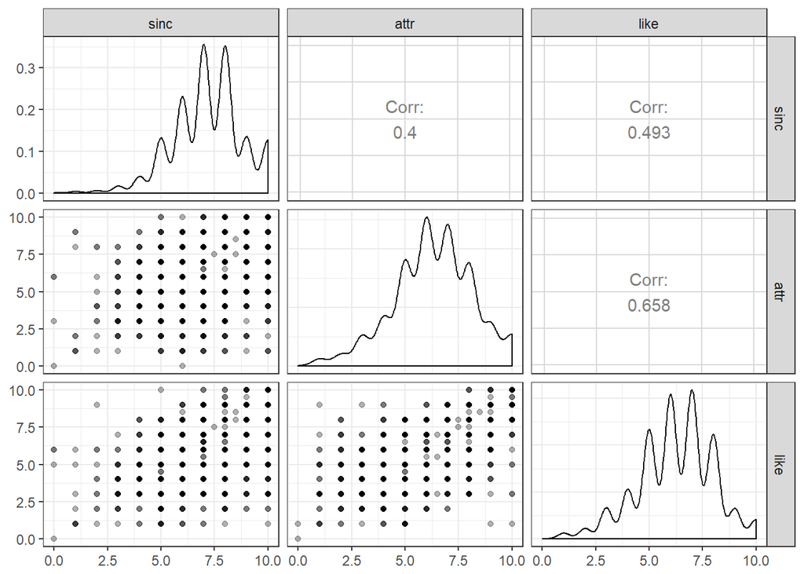

```r
homens = advertising %>%
  filter(gender == 1, like != 'NA', sinc != 'NA', attr != 'NA')

homens %>%
  select(sinc, attr, like) %>%
  ggpairs(lower = list(continuous = wrap("points", alpha = 0.3)))
```

Podemos perceber através do gráfico acima que existe uma correlação positiva para as duas características, para a característica sinceridade (0.493) e para atração (0.658), com o fato dos homens gostarem da outra pessoa após o encontro.

## Primeiro modelo (Homens)

Para começar a análise consideraremos os dois preditores (sinc e attr) no nosso modelo, como mostra o gráfico abaixo.

```r
homens_model = lm(like ~ sinc + attr, data = homens)

plot_model_homens = homens %>%
  data_grid(sinc = seq_range(sinc, 10), # Cria um vetor de 10 valores no range de sinc
            attr = seq_range(attr, 4)) %>%  # Vetor de 4 valores no range de attr
  add_predictions(homens_model)

glimpse(plot_model_homens)
```

```
## Observations: 40
## Variables: 3
## $ sinc <dbl> 0.000000, 0.000000, 0.000000, 0.000000, 1.111111, 1.11111...
## $ attr <dbl> 0.000000, 3.333333, 6.666667, 10.000000, 0.000000, 3.3333...
## $ pred <dbl> 0.8772255, 2.5965415, 4.3158575, 6.0351735, 1.2016600, 2....
```

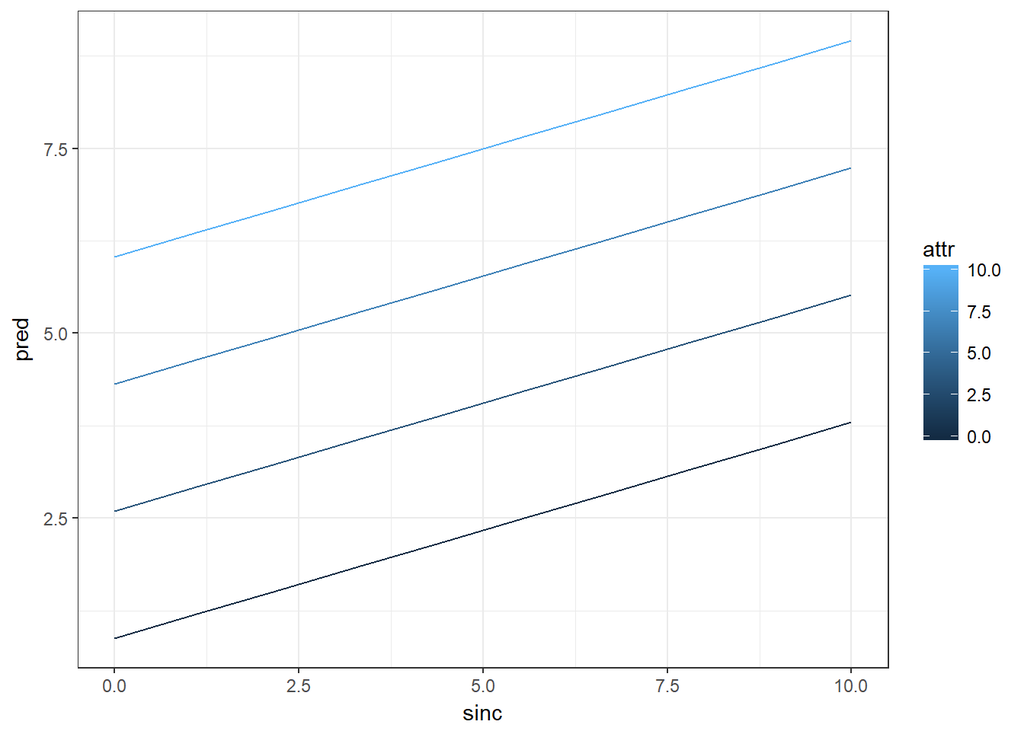

```r
plot_model_homens %>%
  ggplot(aes(x = sinc, y = pred)) +
  geom_line(aes(group = attr, colour = attr))
```

Vamos analisar os resíduos para cada preditor do modelo:

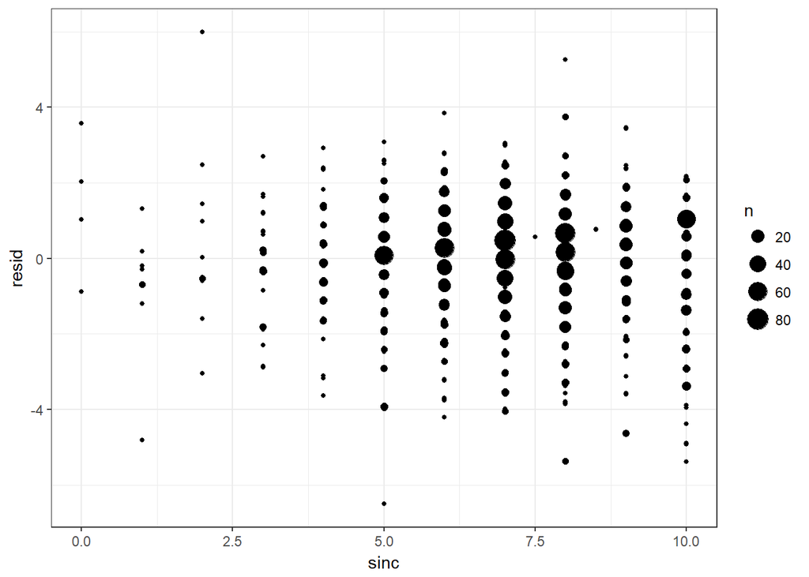

```r
adv_augmented = homens %>%
  add_predictions(homens_model) %>%
  add_residuals(homens_model)

#Resíduos (sinceridade)
adv_augmented %>%
  ggplot(aes(x = sinc)) +
  geom_count(aes(y = resid))
```

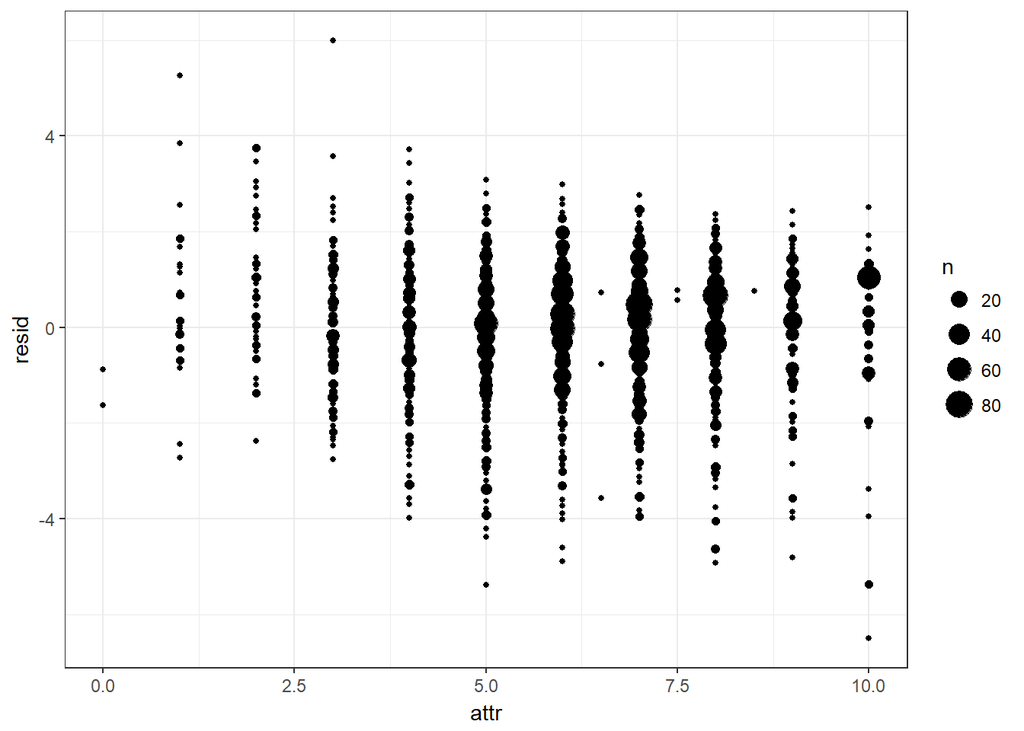

```r
#Resíduos (atração)
adv_augmented %>%
  ggplot(aes(x = attr)) +
  geom_count(aes(y = resid))
```

Pelos gráficos mostrados acima podemos perceber que não há nada alarmante em termos de valores extremos, sem relações obviamente não-lineares e nem heteroscedasticidade, portanto vamos analisar os coeficientes e o modelo.

```r
tidy(homens_model, conf.int = TRUE) %>%
  select(-std.error, -p.value)
```

```
##          term  estimate statistic  conf.low conf.high
## 1 (Intercept) 0.8772255  7.092912 0.6346997 1.1197513
## 2        sinc 0.2919911 17.177196 0.2586570 0.3253252
## 3        attr 0.5157948 34.308824 0.4863138 0.5452758
```

Através dos coeficientes encontrados para o modelo da avaliação dos homens em relação a seus encontros, podemos afirmar a partir dos intervalos de confiança, que as características sinceridade e atração são significativas. Também podemos perceber que a característica atração(attr) é quase o dobro mais relevante que a característica sinceridade(sinc), em relação aos homens gostarem de outra pessoa.

```r
glance(homens_model, conf.int = TRUE)
```

```
##   r.squared adj.r.squared    sigma statistic p.value df    logLik      AIC
## 1 0.4955544      0.495126 1.252031  1156.746       0  3 -3874.358 7756.715
##        BIC deviance df.residual
## 1 7779.777 3691.657        2355
```

# Mulheres avaliando seus encontros

Semelhante ao que fizemos anteriormente, iremos filtrar os dados com pessoas de gênero feminino, para que assim possamos saber como as mulheres avaliaram seus encontros apartir das características *sinceridade* e *atração* após seus encontros no *speed dating*.

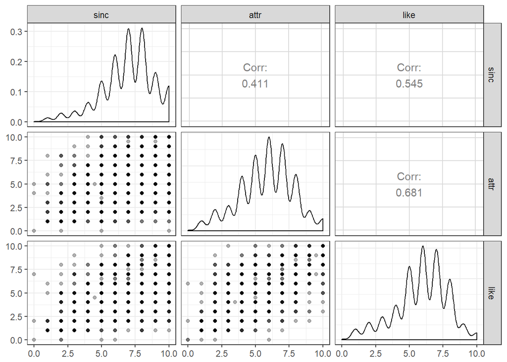

```r
mulheres = advertising %>%
  filter(gender == 0, like != 'NA', sinc != 'NA', attr != 'NA')

mulheres %>%
  select(sinc, attr, like) %>%
  ggpairs(lower = list(continuous = wrap("points", alpha = 0.3)))
```

Podemos perceber através do gráfico acima que existe uma correlação positiva para as duas características, para a característica sinceridade (0.545) e para atração (0.681), com o fato das mulheres gostarem da outra pessoa após o encontro.

## Segundo modelo (Mulheres)

Para começar a análise consideraremos os dois preditores (sinc e attr) no nosso modelo, como mostra o gráfico abaixo.

```r
mulheres_model = lm(like ~ sinc + attr, data = mulheres)

plot_model_mulheres = mulheres %>%
  data_grid(sinc = seq_range(sinc, 10), # Crie um vetor de 10 valores no range de sinc
            attr = seq_range(attr, 4)) %>%  # Vetor de 4 valores no range de attr
  add_predictions(mulheres_model)

glimpse(plot_model_mulheres)
```

```
## Observations: 40
## Variables: 3
## $ sinc <dbl> 0.000000, 0.000000, 0.000000, 0.000000, 1.111111, 1.11111...
## $ attr <dbl> 0.000000, 3.333333, 6.666667, 10.000000, 0.000000, 3.3333...
## $ pred <dbl> 0.5901384, 2.3607509, 4.1313635, 5.9019760, 0.9428240, 2....
```

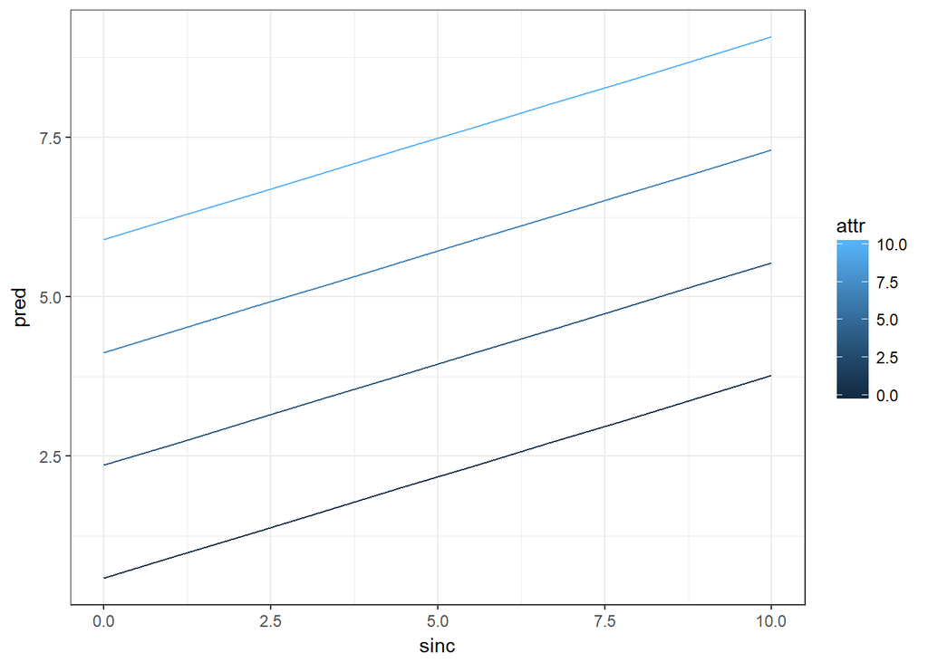

```r
plot_model_mulheres %>%
  ggplot(aes(x = sinc, y = pred)) +
  geom_line(aes(group = attr, colour = attr))
```

Vamos analisar os resíduos para cada preditor do modelo:

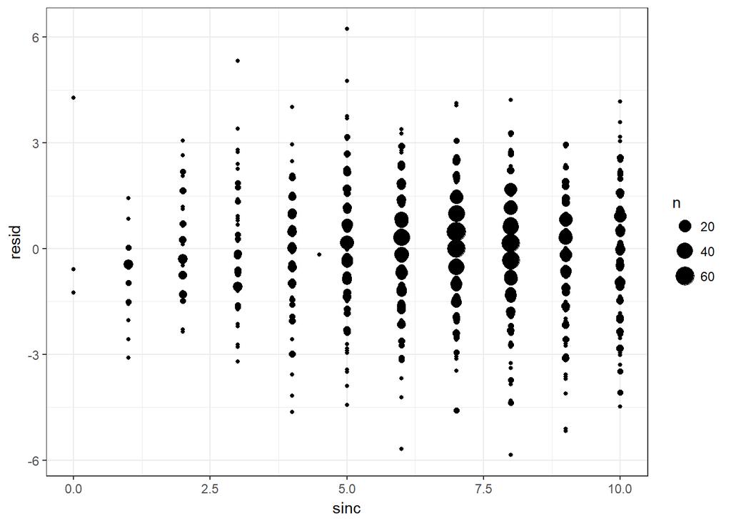

```r
adv_augmented = mulheres %>%
  add_predictions(mulheres_model) %>%
  add_residuals(mulheres_model)

#Resíduos (sinceridade)
adv_augmented %>%
  ggplot(aes(x = sinc)) +
  geom_count(aes(y = resid))
```

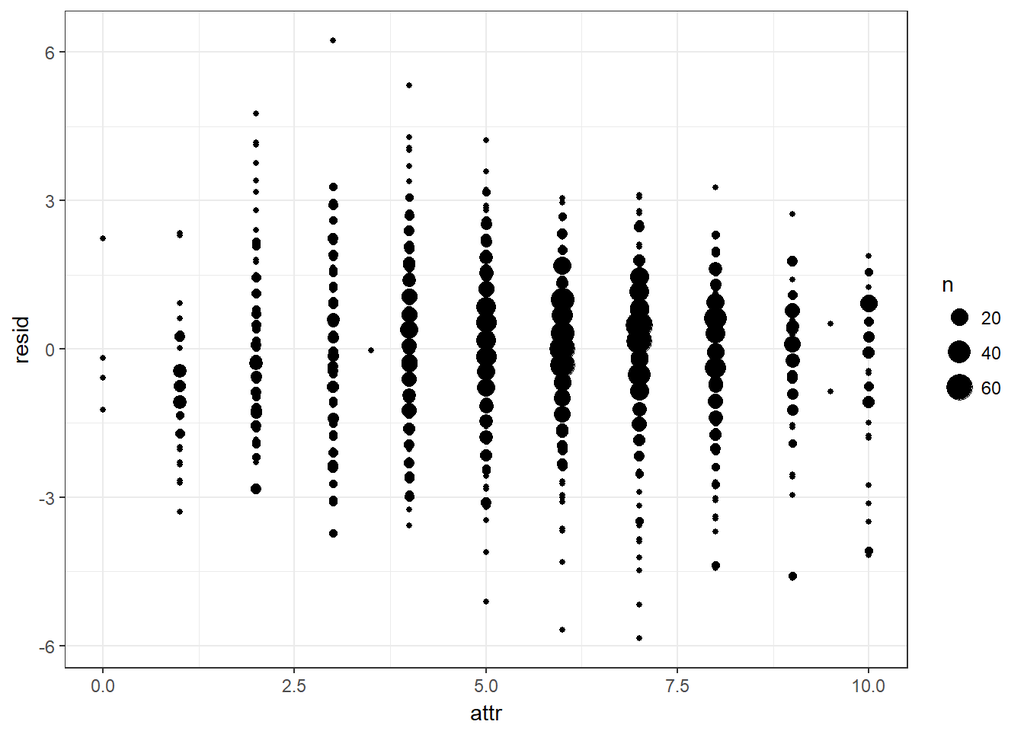

```r
#Resíduos (atração)
adv_augmented %>%
  ggplot(aes(x = attr)) +
  geom_count(aes(y = resid))
```

Pelos gráficos mostrados acima podemos perceber que não há nada alarmante em termos de valores extremos, sem relações obviamente não-lineares e nem heteroscedasticidade, portanto vamos analisar os coeficientes e o modelo.

```r
tidy(mulheres_model, conf.int = TRUE) %>%
  select(-std.error, -p.value)
```

```
##          term  estimate statistic  conf.low conf.high
## 1 (Intercept) 0.5901384  5.497268 0.3796266 0.8006501
## 2        sinc 0.3174171 21.103432 0.2879222 0.3469120
## 3        attr 0.5311838 36.344497 0.5025238 0.5598437
```

Através dos coeficientes encontrados para o modelo da avaliação das mulheres em relação a seus encontros, podemos afirmar a partir dos intervalos de confiança, que as características sinceridade e atração são significativas. Também podemos perceber que a característica atração(attr) é mais relevante que a característica sinceridade(sinc), em relação as mulheres gostarem de outra pessoa.

```r
glance(mulheres_model, conf.int = TRUE)
```

```
##   r.squared adj.r.squared    sigma statistic p.value df    logLik      AIC
## 1 0.5482898     0.5479097 1.293526  1442.612       0  3 -3988.118 7984.235
##        BIC deviance df.residual
## 1 8007.335 3977.219        2377
```

Pelos dados acima ficamos cientes que nosso modelo explica aproximadamente 54% da variação dos dados, neste caso o modelo explicou melhor que o modelo da avaliação dos homens. Portanto, podemos considerar que a variável dependente *like* pode ser bem explicada pelas duas características, sinceridade e atração.

# Visão geral dos resultados apresentados

Podemos ver resultados semelhantes nos dois modelos e verificar que tanto os homens quanto as mulheres após esse encontro *speed dating* acham que a característica atração tem maior relação com o fato da pessoa, no geral, gostar da outra. Por isso, aqueles que se consideram atraentes se dão bem nesses encontros :)